# Final Project Phase 4

## Team Information

- Group 2: Pied Piper
- President Trump Twitter Analysis & Election Simulation
- Alex Bzdel - abzdel@bryant.edu
- Zach Galante - zgalante@bryant.edu
- Robert Mitchell - rmitchell2@bryant.edu

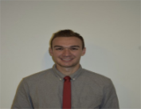

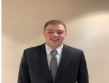

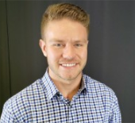

# Abstract

```
We plan to explore Donald Trump’s approval rating based on tweets regarding the US stimulus checks as well as tweets regarding coronavirus. We will explore how Trump's approval rating moves across time in conjunction with these tweets.  Our goal is to see if there is a correlation between the number (and sentiment) of tweets with a keyword and the approval rating. We will annotate key dates from the Trump Administration's coronavirus timeline on our plots as well. We will then take the results from this analysis and see how they correlate to the winner of our election simulation.


Part 1 will deal with Trump's approval rating as compared to our scraped tweets
Part 2 will produce an election simulation based off of current tweets (sample of 10 states)
```

## Keywords & hashtags:

- keywords: Trump, Stimulus Check, $1200, covid19, coronavirus
- hashtags: #trump, #stimuluscheck, #money

## Hypotheses

```
1) President Trump’s approval rating has increased with the number of “positive sentiment” tweets about the stimulus checks distributed by the US government.  The more tweets involving stimulus checks that have highly rated words as determined by sentiment analysis, the higher we believe Trump’s approval rating will be.
2) Sentiment ratings for the tweets will show an increase after the stimulus checks actually start to be distributed.
3) That Trump’s approval rating is going to reflect the current state of the country and that it will also be reflected in the results of the 2020 election.
```

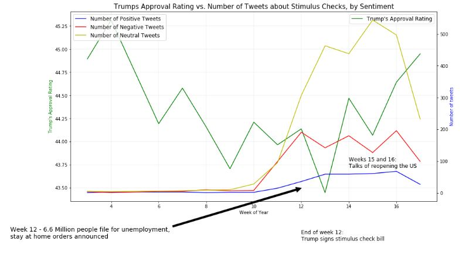

One of our final plots on Trump's Approval Rating vs Stimulus Check Tweets is pictured above

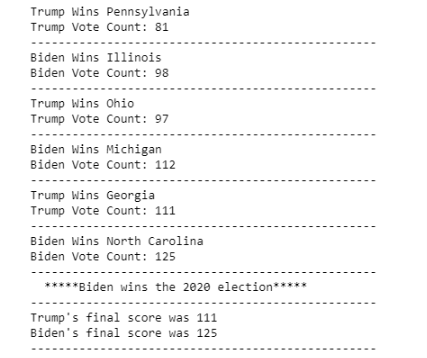

Final simulation example above

# Part 1: Tracking Trump's Approval Rating

```python
# imports
import numpy as np
import pandas as pd
#import tweepy
#import twython

import json
import csv
import os
import codecs
import time
import gender_guesser.detector as gender
from textblob import TextBlob
from wordcloud import WordCloud, STOPWORDS
import seaborn as sns
import matplotlib.pyplot as plt
import re
%matplotlib inline
```

## Description of the Data - Part 1

### Scraper(s) used

```python
#--------- NOTE THAT THIS CELL IS NOT SUPPOSED TO RUN -------------------
import time
from random import seed
from random import randint
# seed random number generator
seed(1)
from datetime import date, datetime, timedelta

def datespan(startDate, endDate, delta=timedelta(days=7)):
    currentDate = startDate
    while currentDate < endDate:
        yield currentDate
        currentDate += delta

text_query = "Stimulus Check"
start_of_period = date(2020, 1, 4)
end_of_period   = date(2020, 5, 2)
start_of_week = start_of_period
week_plus_1_start = start_of_period + timedelta(days=7)

for i, week_plus_1_start in enumerate(datespan(week_plus_1_start, end_of_period, delta=timedelta(days=7))):
    print(f"week {i}, start of week: {start_of_week} {week_plus_1_start}")
    get_tweet_result(text_query = text_query, since_date = f"{start_of_week}",
                 until_date = f"{week_plus_1_start}", count = 500)
    time.sleep(randint(20, 90))

    start_of_week = week_plus_1_start
```

```
week 0, start of week: 2020-01-04 2020-01-11
```

[output not shown]

### Attempt at pulling user data (failed scraper)

Citation for scraper: https://github.com/taspinar/twitterscraper

```python
#--------- NOTE THAT THIS CELL IS NOT SUPPOSED TO RUN -------------------
from twitterscraper.query import query_user_info
import pandas as pd
from multiprocessing import Pool
import time
from IPython.display import display
import random


global twitter_user_info
twitter_user_info=[]


def get_user_info(twitter_user):
    """
    An example of using the query_user_info method
    :param twitter_user: the twitter user to capture user data
    :return: twitter_user_data: returns a dictionary of twitter user data
    """
    user_info = query_user_info(user= twitter_user)
    twitter_user_data = {}
    twitter_user_data["user"] = user_info.user
    twitter_user_data["fullname"] = user_info.full_name
    twitter_user_data["location"] = user_info.location
    twitter_user_data["blog"] = user_info.blog
    twitter_user_data["date_joined"] = user_info.date_joined
    twitter_user_data["id"] = user_info.id
    twitter_user_data["num_tweets"] = user_info.tweets
    twitter_user_data["following"] = user_info.following
    twitter_user_data["followers"] = user_info.followers
    twitter_user_data["likes"] = user_info.likes
    twitter_user_data["lists"] = user_info.lists

    return twitter_user_data


def main():
    start = time.time()
   # users = list(df.username.values) # pass list of usernames into main() function
    #users = ['A3Patriot']
    users = ['A3Patriot', 'whaley1212', 'Janb723Branam', 'jonsaxon67',
       'JLaroc318', 'MamaR130', 'cjstockton67', 'NotTheMacAnon1',
       'VBrown13245591', 'bradyswenson', 'NoelJTom', 'glasscock_keny',
       'cajunvincent', 'grumpy_idiot', 'fwdcrocblu', 'TerryAnastasio',
       'LMenssen', 'AmericanEarlR', 'Frankd06830', 'cchriss147',
       'mtrwf11', 'Isaac_Visage', None]
    pool = Pool(8)
    for user in pool.map(get_user_info,users):
        if True: # if/else meant to fix the following error: NoneType object has no attribute 'User'
            twitter_user_info.append(user)
            time.sleep(random.randint(1,10))
        elif False:
            print('an error has occurred')
            break

        # while true else break

    cols=['id','fullname','date_joined','location','blog', 'num_tweets','following','followers','likes','lists']
        #cols=['id','date_joined','location','num_tweets','followers']

data_frame = pd.DataFrame(twitter_user_info, index=main().users, columns=cols)
        # save data_frame as a global variable after running this
data_frame.index.name = "Users"
data_frame.sort_values(by="followers", ascending=False, inplace=True, kind='quicksort', na_position='last')
elapsed = time.time() - start
print(f"Elapsed time: {elapsed}")
display(data_frame)


if __name__ == '__main__':
    main()
```

[output not shown]

### Data Description

Our first analysis involves data with tweets involving keywords dating back to January 2020

```
* meant to analyze tweet counts and sentiments across time
* drawback: no user data available (followers, location, etc.)
```

- **We scraped the following tweet characteristics via GenOldTweets**:
  - Formatted Date of tweet
  - Author ID (user ID)
  - Username
  - User Location
  - Tweet Text
  - Hashtags
  - Mentions
  - to
    - who the tweet is addressed to - if anyone
  - Tweet URL
  - Replies
  - Retweets
  - Favorites
  - Permalink
- **We then added the following**:
  - filtered_text
  - retweet_flags
  - Polarity_Score
  - SubjectivityScore
  - sentimentLabel

  #### Third-Party Data For our third party data, we will be using Donald Trump's approval rating across the aforementioned timespan (Jan-Present). We will primarily be using this to compare the first dataset to his approval rating and see how they compare. This data is from fivethirtyeight.com

#### Data Processing Tasks

For both sets of data, a big step in processing is sentiment analysis. We will be producing visualizations of the number of tweets about different keywords in the context of sentiment. Additionally, we will be binning every week (there are 17) for our visualization x-axes to depict how sentiments (of both certain keywords and total tweets) and approval ratings have changed across time. We will also be creating three sub-DataFrames (one for each sentiment) and search for keywords again to get a more detailed view on the sentiment of tweets vs. Trump's Approval Rating

#### When and How Long You Scraped Twitter

- we scraped twitter on 4/30 and 5/1 for an hour each day split between each of our three group members

### Load in Data

```python
import pandas as pd
import numpy as np
hashtagTrump = pd.read_csv("Group_2_Phase_4_#Trump_0k_tweets.csv")
hashtagTrump.columns = ['formatted_date', "author_id",  "username",  "geo", "text", "hashtags", 'mentions', "to", "urls",  'replies', 'retweets',  "favorites", 'permalink']
new_money = pd.read_csv("Group_2_Phase_4_$1200_0k_tweets.csv")
new_money.columns = ['formatted_date', "author_id",  "username",  "geo", "text", "hashtags", 'mentions', "to", "urls",  'replies', 'retweets',  "favorites", 'permalink']
a = new_money.append(hashtagTrump, ignore_index = True)
hash_stimCheck = pd.read_csv("Group_2_Phase_4_Copy of #stimuluscheck_0k_tweets.csv")
hash_stimCheck.columns = ['formatted_date', "author_id",  "username",  "geo", "text", "hashtags", 'mentions', "to", "urls",  'replies', 'retweets',  "favorites", 'permalink']
b = a.append(hash_stimCheck, ignore_index = True)
coronavirus = pd.read_csv("Group_2_Phase_4_coronavirus_0k_tweets.csv")
coronavirus.columns = ['formatted_date', "author_id",  "username",  "geo", "text", "hashtags", 'mentions', "to", "urls",  'replies', 'retweets',  "favorites", 'permalink']
c = b.append(coronavirus, ignore_index = True)
COVID19 = pd.read_csv("Group_2_Phase_4_COVID19_0k_tweets.csv")
COVID19.columns = ['formatted_date', "author_id",  "username",  "geo", "text", "hashtags", 'mentions', "to", "urls",  'replies', 'retweets',  "favorites", 'permalink']
d = c.append(COVID19, ignore_index = True)
stim_check = pd.read_csv("Group_2_Phase_4_Stimulus_Check_0k_tweets.csv")
stim_check.columns = ['formatted_date', "author_id",  "username",  "geo", "text", "hashtags", 'mentions', "to", "urls",  'replies', 'retweets',  "favorites", 'permalink']
e = d.append(stim_check, ignore_index = True )
Trump = pd.read_csv("Group_2_Phase_4_Trump_0k_tweets.csv")
Trump.columns= ['formatted_date', "author_id",  "username",  "geo", "text", "hashtags", 'mentions', "to", "urls",  'replies', 'retweets',  "favorites", 'permalink']
df = e.append(Trump, ignore_index = True)
df.head()
```

|  | formatted_date | author_id | username | geo | text | hashtags | mentions | to | urls | replies | retweets | favorites | permalink |
| --- | --- | --- | --- | --- | --- | --- | --- | --- | --- | --- | --- | --- | --- |
| 0 | Fri Apr 10 23:59:57 +0000 2020 | 2.716171e+08 | ForeverMe_MsB | NaN | I got my 1200$y'all | NaN | NaN | NaN | NaN | 1 | 0 | 5 | https://twitter.com/ForeverMe_MsB/status/12487... |
| 1 | Fri Apr 10 23:59:48 +0000 2020 | 4.970938e+07 | _carceeexoxo | NaN | Idk why ppl who probably have 5.00 in their ac... | NaN | NaN | NaN | NaN | 0 | 0 | 1 | https://twitter.com/_carceeexoxo/status/124876... |
| 2 | Fri Apr 10 23:59:45 +0000 2020 | 1.239146e+08 | bitcoinization | NaN | The open market can sell their Bitcoins as muc... | NaN | NaN | mikealfred | NaN | 1 | 0 | 3 | https://twitter.com/bitcoinization/status/1248... |
| 3 | Fri Apr 10 23:59:44 +0000 2020 | 2.826924e+09 | 4rdaSquad | NaN | I’ll slide all 1200 wassup | NaN | NaN | TeannaTrump | https://twitter.com/TeannaTrump/status/1248760... | 0 | 0 | 0 | https://twitter.com/4rdaSquad/status/124876262... |
| 4 | Fri Apr 10 23:59:39 +0000 2020 | 5.381119e+08 | FeIipe__ | NaN | That $1200 just hit for me check dm | NaN | NaN | TeannaTrump | NaN | 1 | 1 | 4 | https://twitter.com/FeIipe__/status/1248762600... |

#### Approval rating data

```python
approval_df = pd.read_csv('Group_2_Phase_4_pollist.csv')
approval_df.head()
```

|  | president | subgroup | modeldate | startdate | enddate | pollster | grade | samplesize | population | weight | ... | disapprove | adjusted_approve | adjusted_disapprove | multiversions | tracking | url | poll_id | question_id | createddate | timestamp |
| --- | --- | --- | --- | --- | --- | --- | --- | --- | --- | --- | --- | --- | --- | --- | --- | --- | --- | --- | --- | --- | --- |
| 0 | Donald Trump | Voters | 4/30/2020 | 5/28/2019 | 4/30/2020 | YouGov | B- | 796 | rv | 0.115784 | ... | 52.0 | 43.27513 | 51.554317 | NaN | NaN | https://d25d2506sfb94s.cloudfront.net/cumulus_... | 58178 | 94719 | 6/3/2019 | 4/30/2020 15:46 |
| 1 | Donald Trump | Voters | 4/30/2020 | 5/29/2019 | 4/30/2020 | YouGov | B- | 771 | rv | 0.112745 | ... | 54.0 | 43.27513 | 53.554317 | NaN | NaN | https://d25d2506sfb94s.cloudfront.net/cumulus_... | 58179 | 94721 | 6/3/2019 | 4/30/2020 15:46 |
| 2 | Donald Trump | Voters | 4/30/2020 | 5/30/2019 | 4/29/2020 | YouGov | B- | 734 | rv | 0.107394 | ... | 54.0 | 43.27513 | 53.554317 | NaN | NaN | https://d25d2506sfb94s.cloudfront.net/cumulus_... | 58180 | 94723 | 6/3/2019 | 4/30/2020 15:46 |
| 3 | Donald Trump | Voters | 4/30/2020 | 5/31/2019 | 4/29/2020 | YouGov | B- | 740 | rv | 0.107772 | ... | 50.0 | 45.27513 | 49.554317 | NaN | NaN | https://d25d2506sfb94s.cloudfront.net/cumulus_... | 58181 | 94725 | 6/3/2019 | 4/30/2020 15:46 |
| 4 | Donald Trump | Voters | 4/30/2020 | 6/1/2019 | 4/29/2020 | YouGov | B- | 728 | rv | 0.105535 | ... | 53.0 | 43.27513 | 52.554317 | NaN | NaN | https://d25d2506sfb94s.cloudfront.net/cumulus_... | 58182 | 94727 | 6/3/2019 | 4/30/2020 15:46 |

5 rows × 22 columns

## Data Cleaning

```python
!pip install nltk
```

```python
# deal with nots
!pip install TextBlob
```

```python
import numpy as np
import pandas as pd
#import tweepy
#import twython

import json
import csv
import os
import codecs
import time
import gender_guesser.detector as gender
from textblob import TextBlob
from wordcloud import WordCloud, STOPWORDS
import seaborn as sns
import matplotlib.pyplot as plt
import re
%matplotlib inline
```

```python
import nltk
nltk.download('stopwords')
nltk.download('punkt')
```

```
True
```

```python
from nltk.corpus import stopwords
from nltk.tokenize import word_tokenize
import re
stop_words = set(stopwords.words('english'))


def remove_url(txt):
    """Replace URLs found in a text string with nothing
    (i.e. it will remove the URL from the string).
    """
    return re.sub("([^0-9A-Za-z \t])|(\w+:\/\/\S+)", "", txt)

def remove_stop_words(txt):
    """lower case the text, and DROP stop words. """
    return " ".join([w for w in word_tokenize(txt.lower()) if not w in stop_words])

def preprocess_tweet_text(txt):
    return remove_stop_words(remove_url(txt))
```

```python
df.text.isnull().sum()
df.text = df.text.fillna(' ') # fill nulls w/ empty string
```

```python
# Remove URLs and Stop Words
df['filtered_text'] = df.text.apply(preprocess_tweet_text)

#retweet
df['retweet_flags'] = df.text.str.startswith('RT')
```

### Create week bins

```python
approval_df.enddate = pd.to_datetime(approval_df.enddate)
approval_df['week_bins'] = approval_df.enddate.dt.week
```

```python
approval_df = approval_df.where(approval_df['week_bins']!=18)
```

```python
df.formatted_date = pd.to_datetime(df.formatted_date)
df['week_bins'] = df.formatted_date.dt.week
```

### Calculate Polarity

```python
df['PolarityScore'] = df.filtered_text.apply(lambda txt:  TextBlob(txt).polarity)
df['SubjectivityScore'] = df.filtered_text.apply(lambda txt:  TextBlob(txt).subjectivity)
```

```python
def sentiment_bins(data):
    if data <= -0.5:
        grouping = 'Strong-Negative'
    elif data > -0.5 and data < 0.0:
        grouping = 'Mild-Negative'
    elif data > 0.0 and data < 0.5:
        grouping = 'Mild Positive'
    elif data >=0.5:
        grouping = 'Strong-Positive'
    else:
        grouping = 'Neutral'
    return grouping

df['sentimentLabel'] = df['PolarityScore'].apply(sentiment_bins)
#These bins should be  used later for graphing results.
```

```python
df['sentiment'] = df.PolarityScore.apply(sentiment_bins)
df.head()
```

|  | formatted_date | author_id | username | geo | text | hashtags | mentions | to | urls | replies | retweets | favorites | permalink | filtered_text | retweet_flags | week_bins | PolarityScore | SubjectivityScore | sentimentLabel | sentiment |
| --- | --- | --- | --- | --- | --- | --- | --- | --- | --- | --- | --- | --- | --- | --- | --- | --- | --- | --- | --- | --- |
| 0 | 2020-04-10 23:59:57+00:00 | 2.716171e+08 | ForeverMe_MsB | NaN | I got my 1200$y'all | NaN | NaN | NaN | NaN | 1 | 0 | 5 | https://twitter.com/ForeverMe_MsB/status/12487... | got 1200yall | False | 15 | 0.000000 | 0.000000 | Neutral | Neutral |
| 1 | 2020-04-10 23:59:48+00:00 | 4.970938e+07 | _carceeexoxo | NaN | Idk why ppl who probably have 5.00 in their ac... | NaN | NaN | NaN | NaN | 0 | 0 | 1 | https://twitter.com/_carceeexoxo/status/124876... | idk ppl probably 500 account acting good 12000... | False | 15 | 0.366667 | 0.466667 | Mild Positive | Mild Positive |
| 2 | 2020-04-10 23:59:45+00:00 | 1.239146e+08 | bitcoinization | NaN | The open market can sell their Bitcoins as muc... | NaN | NaN | mikealfred | NaN | 1 | 0 | 3 | https://twitter.com/bitcoinization/status/1248... | open market sell bitcoins much like honestly s... | False | 15 | 0.033333 | 0.650000 | Mild Positive | Mild Positive |
| 3 | 2020-04-10 23:59:44+00:00 | 2.826924e+09 | 4rdaSquad | NaN | I’ll slide all 1200 wassup | NaN | NaN | TeannaTrump | https://twitter.com/TeannaTrump/status/1248760... | 0 | 0 | 0 | https://twitter.com/4rdaSquad/status/124876262... | ill slide 1200 wassup | False | 15 | -0.500000 | 1.000000 | Strong-Negative | Strong-Negative |
| 4 | 2020-04-10 23:59:39+00:00 | 5.381119e+08 | FeIipe__ | NaN | That $1200 just hit for me check dm | NaN | NaN | TeannaTrump | NaN | 1 | 1 | 4 | https://twitter.com/FeIipe__/status/1248762600... | 1200 hit check dm | False | 15 | 0.000000 | 0.000000 | Neutral | Neutral |

## Workflow Diagrams

First, let's look at our planned workflow for how we will use our scraped tweets DataFrame

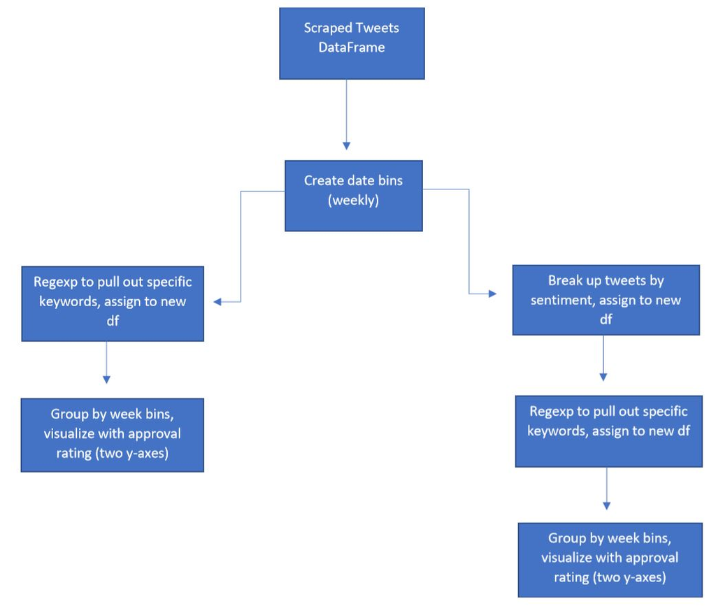

Here's how we plan to use our third party data about Trump's approval rating

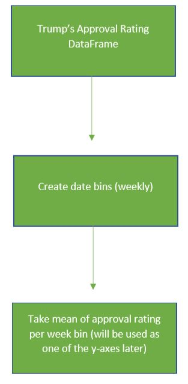

## Visual EDA Prep - Part 1

### Stimulus check tweets (regexp)

```python
import re
df.text = df.text.fillna(" ")
stimuluscheck_df = df[df['text'].str.contains("stimulus check|#stimuluscheck", flags=re.IGNORECASE)]
```

```python
stimuluscheck_df.groupby('week_bins')['text'].count().values #example of the code we will use to plot this
```

```
array([   2,    5,   16,   16,   18,   24,   21,   31,   33,   59,  293,
        747,  980,  963, 1030, 1031,  477])
```

```python
corona_df = df[df['text'].str.contains("1200", flags=re.IGNORECASE)]
arrcorona = corona_df.groupby('week_bins')['text'].count().values

arrcorona= np.insert(arrcorona, 0, 0) #insert 0 at index 0 b/c missing data
```

### Count of tweets for each sentiment

```python
df_pos = df.where((df['sentimentLabel']=='MildPositive') | (df['sentimentLabel']==('Positive')) | (df['sentimentLabel']==('Strong-Positive')))
df_neg = df.where((df['sentimentLabel']=='Mild-Negative') | (df['sentimentLabel']==('Negative')) | (df['sentimentLabel']==('Strong-Negative')))
df_neut = df.where((df['sentimentLabel']=='Neutral'))
```

```python
df_pos = df_pos.dropna(subset=['sentimentLabel'])
df_neg = df_neg.dropna(subset=['sentimentLabel'])
df_neut = df_neut.dropna(subset=['sentimentLabel'])
```

```python
df_pos.groupby('week_bins')['sentimentLabel'].count()
df_neg.groupby('week_bins')['sentimentLabel'].count()
df_neut.groupby('week_bins')['sentimentLabel'].count()
```

```
week_bins
1.0        2
2.0     1101
3.0     1108
4.0     1179
5.0     1164
6.0     1200
7.0     1137
8.0     1138
9.0     1372
10.0    1333
11.0    1967
12.0    2002
13.0    1984
14.0    2069
15.0    2115
16.0    2022
17.0    1597
Name: sentimentLabel, dtype: int64
```

```python
arrneg = df_neg.groupby('week_bins')['text'].count().values
arrneg = np.insert(arrneg, 0, 0)

arrpos = df_pos.groupby('week_bins')['text'].count().values

arrneut = df_neut.groupby('week_bins')['text'].count().values
```

### Stimulus check by sentiment

```python
stimuluscheck_pos_df = df_pos[df_pos['text'].str.contains("stimulus check|#stimuluscheck", flags=re.IGNORECASE)]
stimuluscheck_neg_df = df_neg[df_neg['text'].str.contains("stimulus check|#stimuluscheck", flags=re.IGNORECASE)]
stimuluscheck_neut_df = df_neut[df_neut['text'].str.contains("stimulus check|#stimuluscheck", flags=re.IGNORECASE)]
```

```python
approval_temp_y = approval_df.groupby('week_bins')['approve'].mean()
approval_temp_y = approval_temp_y.drop(labels=[1,2,5])

approval_temp_x = approval_df.groupby('week_bins')['approve'].mean().index
approval_temp_x = approval_temp_x.drop(labels=[1,2,5])

stimcheckneg = stimuluscheck_neg_df.groupby('week_bins')['sentimentLabel'].count()
stimcheckneg = stimcheckneg.drop(labels=[5])

stimcheckneut = stimuluscheck_neut_df.groupby('week_bins')['sentimentLabel'].count()
stimcheckneut = stimcheckneut.drop(labels=[1,2,5])
```

### Coronavirus tweets by sentiment

```python
# search for coronavirus tweets by sentiment

corona_pos_df = df_pos[df_pos['text'].str.contains("coronavirus|covid19", flags=re.IGNORECASE)]
corona_neg_df = df_neg[df_neg['text'].str.contains("coronavirus|covid19", flags=re.IGNORECASE)]
corona_neut_df = df_neut[df_neut['text'].str.contains("coronavirus|covid19", flags=re.IGNORECASE)]
```

```python
corona_pos_df.groupby('week_bins')['sentimentLabel'].count()
corona_neg_df.groupby('week_bins')['sentimentLabel'].count()
corona_neut_df.groupby('week_bins')['sentimentLabel'].count()
```

```
week_bins
2.0     169
3.0     253
4.0     323
5.0     274
6.0     283
7.0     301
8.0     310
9.0     592
10.0    526
11.0    650
12.0    694
13.0    708
14.0    719
15.0    668
16.0    687
17.0    541
Name: sentimentLabel, dtype: int64
```

```python
corona_temp_y = approval_df.groupby('week_bins')['approve'].mean()
corona_temp_y = corona_temp_y.drop(labels=[1])

corona_temp_x = approval_df.groupby('week_bins')['approve'].mean().index
corona_temp_x = corona_temp_x.drop(labels=[1])
```

## Visuals and EDA - Part 1

### Number of Stimulus Check Tweets

First, let's explore how Trump's approval rating has changed with the number of tweets about stimulus checks since the beginning of the year

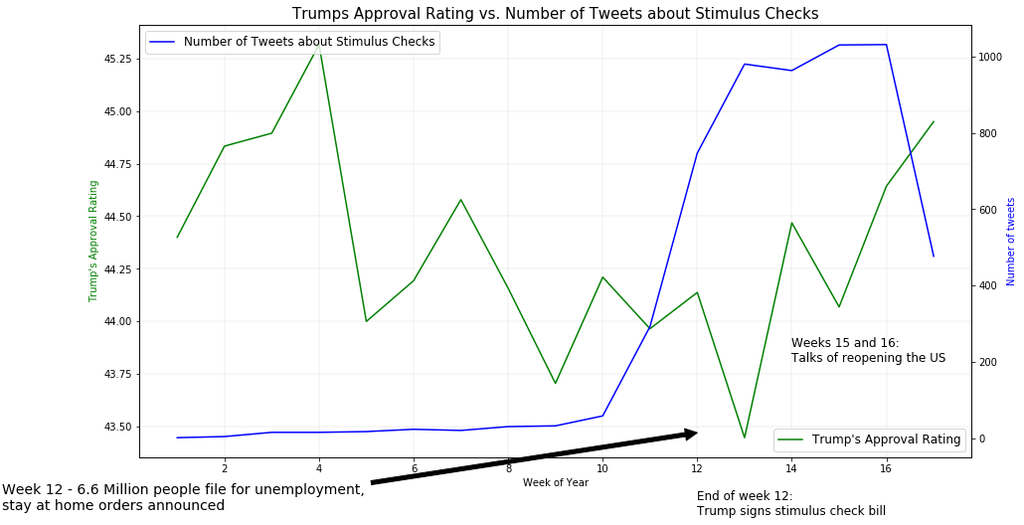

```python
import numpy as np
import matplotlib.pyplot as plt
x = approval_df.groupby('week_bins')['approve'].mean().index
y1 = approval_df.groupby('week_bins')['approve'].mean()
y2 = stimuluscheck_df.groupby('week_bins')['text'].count().values
#y3 = arr1200

fig, ax1 = plt.subplots(figsize=(15,8))

ax1.set_title('Trumps Approval Rating vs. Number of Tweets about Stimulus Checks', fontsize=15)
ax1.grid(color='grey', linestyle='-', linewidth=0.25, alpha=0.5)

#duplicate ax1
ax2 = ax1.twinx()

#ax1 will plot Trump's approval rating, ax2 will plot number of tweets
ax1.plot(x, y1, 'g-')
ax2.plot(x, y2, 'b-')
#ax2.plot(x, y3, 'r-')

# set legends
ax1.legend(["Trump's Approval Rating"], fontsize=12,loc=4)
ax2.legend(["Number of Tweets about Stimulus Checks"], fontsize=12, loc=2)
#ax2.legend(bbox_to_anchor=(0.04, 0.82, 1., .102),labelspacing=0.1,
            #handlelength=0.1, handletextpad=0.1,frameon=False, ncol=4, columnspacing=0.7)


ax1.set_xlabel('Week of Year')
ax1.set_ylabel("Trump's Approval Rating", color='g')
ax2.set_ylabel("Number of tweets", color='b')

# plt.text(6.4,3.3,"""Note on our visualization: We made it so that when there is a
#          null value we replace it with the rank 15 so if an artist is not
#          on that platform's top 10 they go to the bottom""", fontsize = 10)
plt.text(14,200, """Weeks 15 and 16:
Talks of reopening the US""", fontsize = 12)

plt.annotate("""Week 12 - 6.6 Million people file for unemployment,
stay at home orders announced""",
             xy = (12,15), xytext = (2,15), textcoords = ('figure points'),
             arrowprops=dict(facecolor='black'), fontsize = 14)

plt.text(12,-200, """End of week 12:
Trump signs stimulus check bill""", fontsize = 12)




plt.show()

# print('notable dates:')
# print('Week 12 - 6.6 Million people file for unemployment')
```

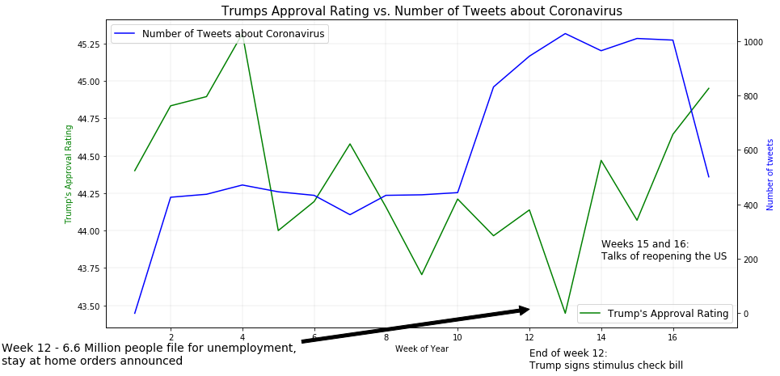

```python
import numpy as np
import matplotlib.pyplot as plt
x = approval_df.groupby('week_bins')['approve'].mean().index
y1 = approval_df.groupby('week_bins')['approve'].mean()
y2 = arrcorona

fig, ax1 = plt.subplots(figsize=(14,7))

ax1.set_title('Trumps Approval Rating vs. Number of Tweets about Coronavirus', fontsize=15)
ax1.grid(color='grey', linestyle='-', linewidth=0.25, alpha=0.5)

#duplicate ax1
ax2 = ax1.twinx()

#ax1 will plot Trump's approval rating, ax2 will plot number of tweets
ax1.plot(x, y1, 'g-')
ax2.plot(x, y2, 'b-')

# set legends
ax1.legend(["Trump's Approval Rating"], fontsize=12, loc=4)
ax2.legend(["Number of Tweets about Coronavirus"], fontsize=12, loc=2)


plt.text(14,200, """Weeks 15 and 16:
Talks of reopening the US""", fontsize = 12)

plt.annotate("""Week 12 - 6.6 Million people file for unemployment,
stay at home orders announced""",
             xy = (12,15), xytext = (2,15), textcoords = ('figure points'),
             arrowprops=dict(facecolor='black'), fontsize = 14)

plt.text(12,-200, """End of week 12:
Trump signs stimulus check bill""", fontsize = 12)



ax1.set_xlabel('Week of Year')
ax1.set_ylabel("Trump's Approval Rating", color='g')
ax2.set_ylabel("Number of tweets", color='b')
#ax.legend((y1, y2), ('label1', 'label2'))
plt.show()
```

### Number of Total Tweets by Sentiment

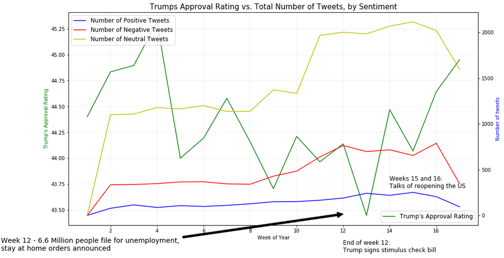

```python
import numpy as np
import matplotlib.pyplot as plt
x = approval_df.groupby('week_bins')['approve'].mean().index
y1 = approval_df.groupby('week_bins')['approve'].mean()
y2 = arrpos
y3 = arrneg
y4 = arrneut

fig, ax1 = plt.subplots(figsize=(15,8))

ax1.set_title('Trumps Approval Rating vs. Total Number of Tweets, by Sentiment', fontsize=15)
ax1.grid(color='grey', linestyle='-', linewidth=0.25, alpha=0.5)

#duplicate ax1
ax2 = ax1.twinx()

#ax1 will plot Trump's approval rating, ax2 will plot number of tweets
ax1.plot(x, y1, 'g-')
ax2.plot(x, y2, 'b-')
ax2.plot(x, y3, 'r-')
ax2.plot(x, y4, 'y-')


# set legends
ax1.legend(["Trump's Approval Rating"], fontsize=12, loc=4)
ax2.legend(["Number of Positive Tweets", "Number of Negative Tweets", "Number of Neutral Tweets"], fontsize=12, loc=2)

plt.text(14,300, """Weeks 15 and 16:
Talks of reopening the US""", fontsize = 12)

plt.annotate("""Week 12 - 6.6 Million people file for unemployment,
stay at home orders announced""",
             xy = (12,15), xytext = (2,15), textcoords = ('figure points'),
             arrowprops=dict(facecolor='black'), fontsize = 14)

plt.text(12,-400, """End of week 12:
Trump signs stimulus check bill""", fontsize = 12)




ax1.set_xlabel('Week of Year')
ax1.set_ylabel("Trump's Approval Rating", color='g')
ax2.set_ylabel("Number of tweets", color='b')
#ax.legend((y1, y2, y3), ('label1', 'label2', 'label3'))


plt.show()
```

### Number of Stimulus Check Tweets by Sentiment

Let's take our positive, negative, and neutral tweets and search for the ones where stimulus check is mentioned

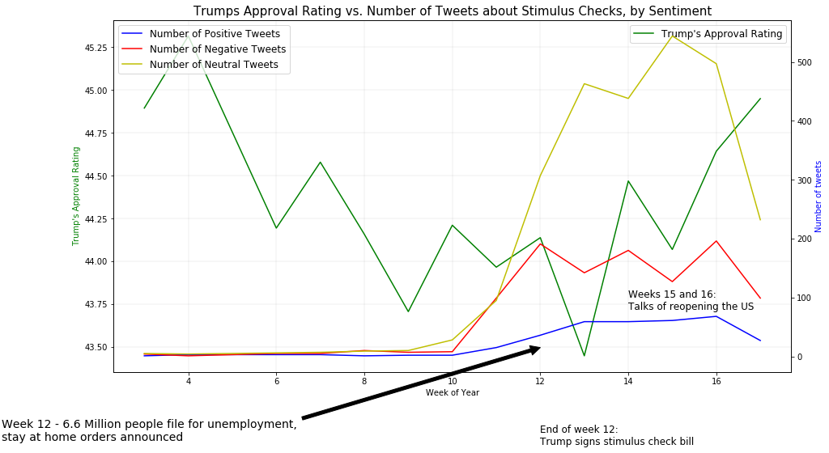

```python
# import numpy as np
import matplotlib.pyplot as plt
x = approval_temp_x
y1 = approval_temp_y
y2 = stimuluscheck_pos_df.groupby('week_bins')['sentimentLabel'].count()
y3 = stimcheckneg
y4 = stimcheckneut

fig, ax1 = plt.subplots(figsize=(15,8))

ax1.set_title('Trumps Approval Rating vs. Number of Tweets about Stimulus Checks, by Sentiment', fontsize=15)
ax1.grid(color='grey', linestyle='-', linewidth=0.25, alpha=0.5)

#duplicate ax1
ax2 = ax1.twinx()

#ax1 will plot Trump's approval rating, ax2 will plot number of tweets
ax1.plot(x, y1, 'g-')
ax2.plot(x, y2, 'b-') # POSITIVE TWEETS
ax2.plot(x, y3, 'r-') # NEGATIVE TWEETS
ax2.plot(x, y4, 'y-') # NEUTRAL TWEETS

# set legends
ax1.legend(["Trump's Approval Rating"], fontsize=12, loc=1)
ax2.legend(["Number of Positive Tweets", "Number of Negative Tweets", "Number of Neutral Tweets"], fontsize=12, loc=2)

plt.text(14,80, """Weeks 15 and 16:
Talks of reopening the US""", fontsize = 12)

plt.annotate("""Week 12 - 6.6 Million people file for unemployment,
stay at home orders announced""",
             xy = (12,15), xytext = (2,15), textcoords = ('figure points'),
             arrowprops=dict(facecolor='black'), fontsize = 14)

plt.text(12,-150, """End of week 12:
Trump signs stimulus check bill""", fontsize = 12)


ax1.set_xlabel('Week of Year')
ax1.set_ylabel("Trump's Approval Rating", color='g')
ax2.set_ylabel("Number of tweets", color='b')

plt.show()
```

### Number of Coronavirus Tweets by Sentiment

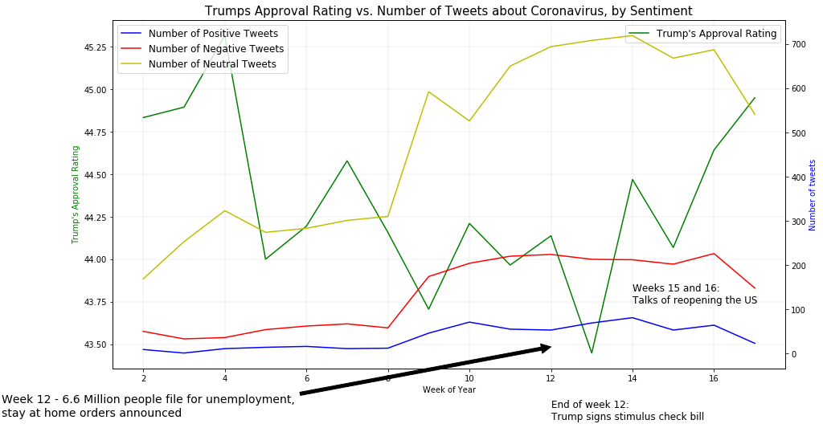

```python
# import numpy as np
import matplotlib.pyplot as plt
x = corona_temp_x
y1 = corona_temp_y
y2 = corona_pos_df.groupby('week_bins')['sentimentLabel'].count()
y3 = corona_neg_df.groupby('week_bins')['sentimentLabel'].count()
y4 = corona_neut_df.groupby('week_bins')['sentimentLabel'].count()

fig, ax1 = plt.subplots(figsize=(15,8))

ax1.set_title('Trumps Approval Rating vs. Number of Tweets about Coronavirus, by Sentiment', fontsize=15)
ax1.grid(color='grey', linestyle='-', linewidth=0.25, alpha=0.5)

#duplicate ax1
ax2 = ax1.twinx()

#ax1 will plot Trump's approval rating, ax2 will plot number of tweets
ax1.plot(x, y1, 'g-')
ax2.plot(x, y2, 'b-') # POSITIVE TWEETS
ax2.plot(x, y3, 'r-') # NEGATIVE TWEETS
ax2.plot(x, y4, 'y-') # NEUTRAL TWEETS

# set legends
ax1.legend(["Trump's Approval Rating"], fontsize=12, loc=1)
ax2.legend(["Number of Positive Tweets", "Number of Negative Tweets", "Number of Neutral Tweets"], fontsize=12, loc=2)

ax1.set_xlabel('Week of Year')
ax1.set_ylabel("Trump's Approval Rating", color='g')
ax2.set_ylabel("Number of tweets", color='b')



plt.text(14,115, """Weeks 15 and 16:
Talks of reopening the US""", fontsize = 12)

plt.annotate("""Week 12 - 6.6 Million people file for unemployment,
stay at home orders announced""",
             xy = (12,15), xytext = (2,15), textcoords = ('figure points'),
             arrowprops=dict(facecolor='black'), fontsize = 14)

plt.text(12,-150, """End of week 12:
Trump signs stimulus check bill""", fontsize = 12)



plt.show()
```

Further analysis of graph will be discussed in the "discussion" and "conclusion" sections

# Part 2: Predicting the 2020 Election

## Description Of The Data - Part 2

## Scraper(s) Used

For this part of the project, we scraped for the same keywords as before, but this time we used the API scraper to get more info for users on current tweets.

```python
from twython import TwythonStreamer
import csv
import json
import codecs
import time
from random import seed
from random import randint
# seed random number generator
seed(1)

tweets_filename = "twitter_output_Trump"

consumer_key = "ND4wRUZRSgRS1NBtb9vRbm96v"
consumer_secret = "z0zxb6QObq4AUU2bA8BBclnIZbDr89vShniSZ9NjMWHUaIJ2AK"
access_token = "1250793114274598913-1mA5LzmdeGsu7PvTD1QpoZymfUPrPl"
access_token_secret = "cqNiCEcr5OsbS5G1t3uAGhZhqabgeu7XVHZluQiJIBVnf"

tweetabbr = []

# In this session we are using the Twitter IDs to gather tweets from those accounts.
AllPDs = ['561106229', '34296669', '974277346252423169', '121222566', '991525350', '378424739',
          '35871927', '304847225']
# Filter out unwanted data for the CSV file. We are saving the entire JSON to a seperate file should we need more data.
def process_tweet(tweet):
    d = {}
    d['hashtags'] = [hashtag['text'] for hashtag in tweet['entities']['hashtags']]
    d['id'] = tweet['id']
    d['text'] = tweet['text']
    d['name'] = tweet['user']['name']
    d['user'] = tweet['user']['screen_name']
    d['user_loc'] = tweet['user']['location']
    d['user_desc'] = tweet['user']['description']
    d['user_followers'] = tweet['user']['followers_count']
    d['user_friends'] = tweet['user']['friends_count']
    d['user_listed'] = tweet['user']['listed_count']
    d['user_created'] = tweet['user']['created_at']
    d['user_favs'] = tweet['user']['favourites_count']
    d['user_statuses'] = tweet['user']['statuses_count']

    return d


# Create a class that inherits TwythonStreamer
class MyStreamer(TwythonStreamer):

    # Received data
    def on_success(self, data):

        # Save full JSON to file
        # TODO : save properly so we can load later directly
        # A tweet JSON record per line
        with open(f'{tweets_filename}.json', 'a') as jsonfile:
            json.dump(data, jsonfile)
            jsonfile.write("\n")

        # Only save tweets in English
        if data['lang'] == 'en':
            tweet_data = process_tweet(data)
            self.save_to_csv(tweet_data)

    # Problem with the API
    def on_error(self, status_code, data):
        print(status_code, data)
        self.disconnect()

    # Save each tweet to csv file
    def save_to_csv(self, tweet):
        with open(f'{tweets_filename}.csv', 'a', encoding="utf8") as file:
            writer = csv.writer(file)
            writer.writerow(list(tweet.values()))

while True:
    try:
        # Instantiate from our streaming class
        stream = MyStreamer(consumer_key, consumer_secret,
                    access_token, access_token_secret)

        # Start the stream - this would capture tweets generated by specific accounts - ex. Harley Davidson's account
        # There are online tools to get the account number using the @ account name.
        # stream.statuses.filter(follow=17169239) #Track uses comma separated list

        # Start the stream - this would capture tweets generated by these accounts
        #stream.statuses.filter(follow=AllPDs) #Track uses comma separated list

        # Start the stream - This stream looks for specific terms (mentions)
        #stream.statuses.filter(track='@VASenate2018,@MariaCantwell,@Susan_Hutch,') #Track uses comma separated list
        stream.statuses.filter(track='Trump', 'Stimulus Check','$1200', 'covid19', 'coronavirus','#trump','#stimuluscheck', '#money' )
#track="Trump, Stimulus Check,stimulus check,trump,government,Government,Republican,owner,owner,Mayor,State Rep,democrat,#trump,#stimuluscheck,#money,#republican,#COVID19,financial crisis"#track="Trump, Stimulus Check,stimulus check,trump,government,Government,Republican,owner,owner,Mayor,State Rep,democrat,#trump,#stimuluscheck,#money,#republican,#COVID19,financial crisis"
    except (KeyboardInterrupt):
        print("Exiting")
        break
    except Exception as e:
        print("error - sleeping " + str(e))
        time.sleep(randint(30, 90)) #suspends (waits) execution of the current thread for a given number of seconds
        continue
```

[output not shown]

## Data Description

Our second analysis involves data scraped from twitter API. This allows us to work more with user data to produce our simulation.

- **We scraped the following tweet characteristics via the API (second set of data)**:
  - Hashtags
  - Tweet ID
  - Tweet text
  - User's display name
  - Username
  - User's location
  - User's description
  - Followers
  - Friends
  - Lists
  - Account creation date
  - Favorites
  - User total tweets
- **We then added the following**:
  - filtered_text
  - retweet_flags
  - Polarity_Score
  - SubjectivityScore
  - sentimentLabel

### Data Processing Tasks

For our second set of data, we will first have to perform sentiment analysis. The first step in this was to get the sentiment bins. We then saw how many neutral values there were, so we did a further analysis on those neutral values to then filter then again by their user_description.

### When And How Long You Scraped Twitter

For this part of the project, we scraped Twitter for about 8 hours continuously on Thursday April 30 2020.

## Load in Data

```python
import pandas as pd
import numpy as np

df= pd.read_csv("Group_2_Phase_4_twitter_output_Trump.csv")
df.columns= ['Hashtags','ID','Tweet_Text','Name','Username','User_Location','User_Description','Followers','Friends','Lists','Account_Creation_Date','Favorites','User_Total_Tweets']
```

### Drop Duplicates

```python
length  = len(df)
new_length = len(df.drop_duplicates())
print(f" The current length of our Dataframe is {length} records")
print(f" The length of our Dataframe after dropping duplicates is {new_length} records" )
```

```
 The current length of our Dataframe is 28861 records
 The length of our Dataframe after dropping duplicates is 28857 records
```

# Simulation Data Cleaning/ Sorting

Importing libraries and functions given to us from Professor Shanahan

```python
# Remove URLs and Stop Words
df['filtered_text'] = df.Tweet_Text.apply(preprocess_tweet_text)

#retweet
df['retweet_flags'] = df.Tweet_Text.str.startswith('RT')

# TODO Add code analyse URLs, their domains, categories etc.
```

```python
# deal with nots
!pip install TextBlob
```

```python
from textblob import TextBlob
df['PolarityScore'] = df.filtered_text.apply(lambda txt:  TextBlob(txt).polarity)
df['SubjectivityScore'] = df.filtered_text.apply(lambda txt:  TextBlob(txt).subjectivity)
```

```python
def sentiment_bins(data):
    if data <= -0.5:
        grouping = 'Strong-Negative'
    elif data > -0.5 and data < 0.0:
        grouping = 'Mild-Negative'
    elif data > 0.0 and data < 0.5:
        grouping = 'Mild Positive'
    elif data >=0.5:
        grouping = 'Strong-Positive'
    else:
        grouping = 'Neutral'
    return grouping

df['sentimentLabel'] = df['PolarityScore'].apply(sentiment_bins)
```

```python
# user locations
df.User_Location.value_counts(dropna = True)
```

```
United States                 716
USA                           253
California, USA               253
Texas, USA                    172
India                         148
                             ...
United States/France            1
North Shore Massachusetts       1
 kashmir (disputed)             1
Northamptonshire                1
Mostazal                        1
Name: User_Location, Length: 8696, dtype: int64
```

# Visual EDA- Part 2

## Further Filtering Neutral Values

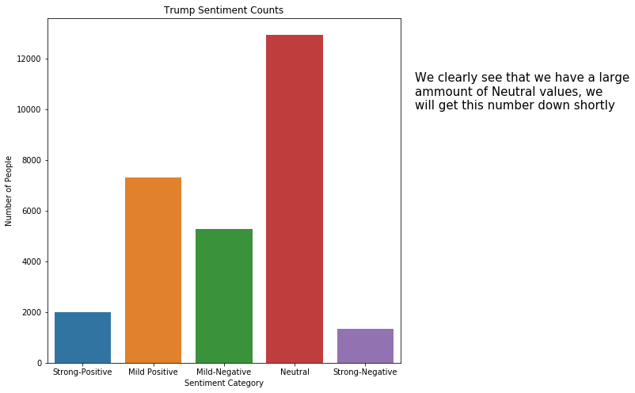

```python
plt.figure(figsize = (8,8))
ax = sns.countplot(x = "sentimentLabel", data = df)
ax.set(title = "Trump Sentiment Counts", xlabel = "Sentiment Category", ylabel = "Number of People")
plt.text(4.7, 10000,"We clearly see that we have a large\nammount of Neutral values, we\nwill get this number down shortly", fontsize = 15)
```

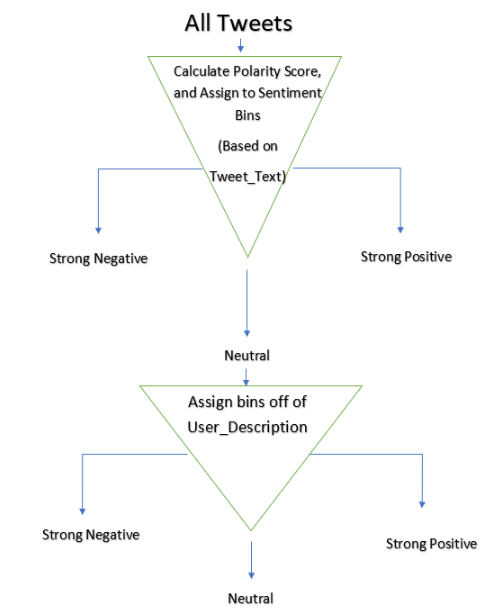

## Creating the Neutral Dataframe

```python
Neutral= df[df['sentimentLabel'].str.contains("Neutral", flags=re.IGNORECASE)]
#Creating a datafrmae of all the Neutral tweets
Neutral['User_Description'] = Neutral.User_Description.fillna('.') # More data cleaning
```

So here we are taking our dataframe of Neutral tweets and then calculating a polarity score for them based off of User_Description to further filter them to be able to get rid of the number of Neutral values.

After looking at some of the User_Descriptions we found that they actually had value as some of them would explicitly state their political affiliation (ex. Patriot Pro-Trump Christian English). The index for this record was 3.

```python
Neutral['PolarityScore'] = Neutral.User_Description.apply(lambda txt:  TextBlob(txt).polarity)
Neutral['SubjectivityScore'] = Neutral.User_Description.apply(lambda txt:  TextBlob(txt).subjectivity)
#Actually creating the Polarity and Subjectivity scores
Neutral['sentimentLabel'] = Neutral['PolarityScore'].apply(sentiment_bins)
#Now putting them into bins
```

We now have the neutral values with an assigned sentiment label, which is based off of the user_description!

```python
Neutral.head()
```

|  | Hashtags | ID | Tweet_Text | Name | Username | User_Location | User_Description | Followers | Friends | Lists | Account_Creation_Date | Favorites | User_Total_Tweets | filtered_text | retweet_flags | PolarityScore | SubjectivityScore | sentimentLabel |
| --- | --- | --- | --- | --- | --- | --- | --- | --- | --- | --- | --- | --- | --- | --- | --- | --- | --- | --- |
| 3 | [] | 1254972505367994368 | RT @RedWingGrips: BREAKING: President Trump ha... | Proud American | ProudQchick | United States | Patriot Pro-Trump Christian English Only @char... | 11759 | 12003 | 16 | Thu Mar 22 16:25:03 +0000 2012 | 144410 | 147254 | rt redwinggrips breaking president trump suspe... | True | 0.00000 | 0.333333 | Neutral |
| 4 | [] | 1254972505497808897 | RT @mog7546: Health experts from the Trump, Ob... | Donald Putin is a TRAITOR | GalindoSherry | Saskatchewan, Canada | #25thAmendmentNow\n\nLove all people...\nEXCEP... | 3081 | 3515 | 2 | Thu Mar 29 04:34:53 +0000 2012 | 93592 | 76353 | rt mog7546 health experts trump obama bush adm... | True | 0.78125 | 0.600000 | Strong-Positive |
| 5 | [] | 1254972505544105984 | RT @costareports: “U.S. intelligence agencies ... | Joni A. Caufield | TL267sister | NaN | We the People...All For One, One For All #Resi... | 3859 | 4547 | 4 | Fri Sep 07 04:42:36 +0000 2012 | 38262 | 37099 | rt costareports us intelligence agencies issue... | True | 0.00000 | 0.000000 | Neutral |
| 9 | [] | 1254972505661616129 | RT @soledadobrien: That ‘somebody’ is you, babe. | Honey | TheHoneyPirate | NaN | . | 307 | 493 | 1 | Fri Apr 17 01:03:49 +0000 2009 | 79521 | 13582 | rt soledadobrien somebody babe | True | 0.00000 | 0.000000 | Neutral |
| 10 | [] | 1254972505837764610 | Trump Blames Plummeting Poll Numbers on People... | MADgenius_123 | MADgenius_123 | 🜨 | everything is politics ... including this account | 3 | 50 | 0 | Fri Jan 10 18:15:23 +0000 2014 | 1 | 2752 | trump blames plummeting poll numbers people pa... | False | 0.00000 | 0.000000 | Neutral |

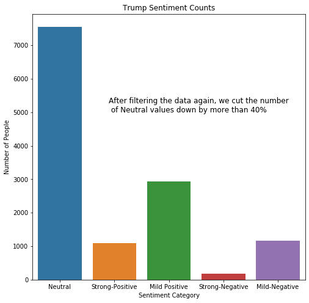

```python
plt.figure(figsize = (8,8))
ax = sns.countplot(x = "sentimentLabel", data = Neutral)
ax.set(title = "Trump Sentiment Counts", xlabel = "Sentiment Category", ylabel = "Number of People")
plt.text(0.9,5000,"After filtering the data again, we cut the number\n of Neutral values down by more than 40%", fontsize = 12)
```

# EDA Part 2

## 2020 Election Simulation

This section includes an elaborate simulation of the 2020 Election based off of the Top 10 states (ranked by number of electoral votes). We then looked at the outcomes of the previous election to determine if a state would be a swing state or not. If the margin of victory was lower than 5% then we determined that the state would be defined as a "Swing State" (Meaning that this state could "swing" sides and belong to the other party in the upcoming election. This also led to theory that on election day, a swing state could be such a close race, and could ultimately be a 50/50 chance for each party (This theory is also further explained in the metric). In addition this is only a small simulation of the actual election, and is determinig the "winner" based off of only the top 10 states for simplicity.

```python
topStates = pd.read_csv("Group_2_Phase_4_Top10States.csv") # The states with the most Electoral votes
topStates #A BLUE STATE= WON BY THE DEMOCRATIC PARTY AND RED MEANING IT WAS WON BY THE REUPUBLICAN PARTY
```

|  | State | Electoral Votes | Difference in % of Votes | Swing State | 2016 Status |
| --- | --- | --- | --- | --- | --- |
| 0 | California | 53 | 28.80% | No | Blue |
| 1 | Texas | 36 | 9.20% | No | Red |
| 2 | New York | 27 | 21.30% | No | Blue |
| 3 | Florida | 27 | 1.30% | Yes | Red |
| 4 | Pennsylvania | 18 | 1.20% | Yes | Red |
| 5 | Illinois | 18 | 16% | No | Blue |
| 6 | Ohio | 16 | 8.60% | No | Red |
| 7 | Michigan | 14 | 0.30% | Yes | Red |
| 8 | Georgia | 14 | 5.70% | No | Red |
| 9 | North Carolina | 13 | 3.80% | Yes | Red |

## How the simulation actually works

In summary, the simulation will follow these steps to determine the winner of the 2020 Election, based off of sentiment and location.

- PLEASE KEEP IN MIND THAT THIS IS FROM TRUMP'S PERSPECTIVE (Negative means Not for Trump, Positive means for Trump)
1. Add up all of the positive and negative tweets for the specified state from the filtered Neutral DataFrame based off of their new label.
2. Do the exact same for the original DataFrame to get a Positive and Negative score
3. Take the number of remaining Neutral values for each state
4. It is now determined if a state is a swing state or not
5. If the state is not a swing state, then the remaining neutral values are given the party that had won the state in the previous election. But if the state is indeed a swing state, it enters into a for loop, where based off of our theory that it's almost a 50/50 chance of winning one of those states, a random number is given. If the random number is even, then those states neutral votes are given to Joe Biden, but if that number comes out to odd, then those votes are given to Donald Trump.
6. Then based off of that determination, we calculate who wins the state based off of who got the most votes.

Below is a screenshot for just one state, this then replicated for every state in the Top 10

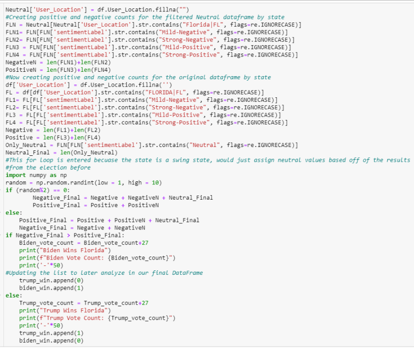

## The Actual Simulation

Please note this this is a live simulation, so each time this cell is ran, it will produce different outputs. For our analysis we used the first output we got from this simulation.

```python
Biden_vote_count = 0
Trump_vote_count = 0
trump_win = []
biden_win = []
# CALIFORNIA--------------------------------------------------------------------------------------------------
Neutral['User_Location'] = df.User_Location.fillna("")
CALN = Neutral[Neutral['User_Location'].str.contains("California|CA", flags=re.IGNORECASE)]
CALN1= CALN[CALN['sentimentLabel'].str.contains("Mild-Negative", flags=re.IGNORECASE)]
CALN2= CALN[CALN['sentimentLabel'].str.contains("Strong-Negative", flags=re.IGNORECASE)]
CALN3 = CALN[CALN['sentimentLabel'].str.contains("Mild-Positive", flags=re.IGNORECASE)]
CALN4 = CALN[CALN['sentimentLabel'].str.contains("Strong-Positive", flags=re.IGNORECASE)]
NegativeN = len(CALN1)+len(CALN2)
PositiveN = len(CALN3)+len(CALN4)
df['User_Location'] = df.User_Location.fillna('')
CA = df[df['User_Location'].str.contains("California|CA", flags=re.IGNORECASE)]
CAL1= CA[CA['sentimentLabel'].str.contains("Mild-Negative", flags=re.IGNORECASE)]
CAL2= CA[CA['sentimentLabel'].str.contains("Strong-Negative", flags=re.IGNORECASE)]
CAL3 = CA[CA['sentimentLabel'].str.contains("Mild-Positive", flags=re.IGNORECASE)]
CAL4 = CA[CA['sentimentLabel'].str.contains("Strong-Positive", flags=re.IGNORECASE)]
Negative = len(CAL1)+len(CAL2)
Positive = len(CAL3)+len(CAL4)
Only_Neutral = CALN[CALN['sentimentLabel'].str.contains("Neutral", flags=re.IGNORECASE)]
Neutral_Final = len(Only_Neutral)
Positive_Final = Positive + PositiveN
Negative_Final = Negative + NegativeN+Neutral_Final
if Negative_Final > Positive_Final:
    Biden_vote_count = Biden_vote_count+53
    print("Biden Wins California")
    print(f"Biden Vote Count: {Biden_vote_count}")
    print('-'*50)
    trump_win.append(0)
    biden_win.append(1)
else:
    Trump_vote_count = Trump_vote_count+53
    print("Trump Wins California")
    print(f"Trump Vote Count: {Trump_vote_count}")
    trump_win.append(1)
    biden_win.append(0)
#TEXAS----------------------------------------------------------------------------------------------
Neutral['User_Location'] = df.User_Location.fillna("")
TXN = Neutral[Neutral['User_Location'].str.contains("Texas|TX", flags=re.IGNORECASE)]
TXN1= TXN[TXN['sentimentLabel'].str.contains("Mild-Negative", flags=re.IGNORECASE)]
TXN2= TXN[TXN['sentimentLabel'].str.contains("Strong-Negative", flags=re.IGNORECASE)]
TXN3 = TXN[TXN['sentimentLabel'].str.contains("Mild-Positive", flags=re.IGNORECASE)]
TXN4 = TXN[TXN['sentimentLabel'].str.contains("Strong-Positive", flags=re.IGNORECASE)]
NegativeN = len(TXN1)+len(TXN2)
PositiveN = len(TXN3)+len(TXN4)
df['User_Location'] = df.User_Location.fillna('')
Neutral['User_Location'] = df.User_Location.fillna("")
TX = df[df['User_Location'].str.contains("Texas|TX", flags=re.IGNORECASE)]
TX1= TX[TX['sentimentLabel'].str.contains("Mild-Negative", flags=re.IGNORECASE)]
TX2= TX[TX['sentimentLabel'].str.contains("Strong-Negative", flags=re.IGNORECASE)]
TX3 = TX[TX['sentimentLabel'].str.contains("Mild-Positive", flags=re.IGNORECASE)]
TX4 = TX[TX['sentimentLabel'].str.contains("Strong-Positive", flags=re.IGNORECASE)]
Negative = len(TX1)+len(TX2)
Positive = len(TX3)+len(TX4)
Only_Neutral = TXN[TXN['sentimentLabel'].str.contains("Neutral", flags=re.IGNORECASE)]
Neutral_Final = len(Only_Neutral)
Positive_Final = Positive + PositiveN+Neutral_Final
Negative_Final = Negative + NegativeN
Neutral_Final = len(Only_Neutral)
if Negative_Final > Positive_Final:
    Biden_vote_count = Biden_vote_count+36
    print("Biden Wins Texas")
    print(f"Biden Vote Count: {Biden_vote_count}")
    print('-'*50)
    trump_win.append(0)
    biden_win.append(1)
else:
    Trump_vote_count = Trump_vote_count+36
    print("Trump Wins Texas")
    print(f"Trump Vote Count: {Trump_vote_count}")
    print('-'*50)
    trump_win.append(1)
    biden_win.append(0)
# NEW YORK------------------------------------------------------------------------------------------------------
Neutral['User_Location'] = df.User_Location.fillna("")
NYN = Neutral[Neutral['User_Location'].str.contains("New York|NY", flags=re.IGNORECASE)]
NYN1= NYN[NYN['sentimentLabel'].str.contains("Mild-Negative", flags=re.IGNORECASE)]
NYN2= NYN[NYN['sentimentLabel'].str.contains("Strong-Negative", flags=re.IGNORECASE)]
NYN3 = NYN[NYN['sentimentLabel'].str.contains("Mild-Positive", flags=re.IGNORECASE)]
NYN4 = NYN[NYN['sentimentLabel'].str.contains("Strong-Positive", flags=re.IGNORECASE)]
NegativeN = len(NYN1)+len(NYN2)
PositiveN = len(NYN3)+len(NYN4)
df['User_Location'] = df.User_Location.fillna('')
NY = df[df['User_Location'].str.contains("New York|NY", flags=re.IGNORECASE)]
NY1= NY[NY['sentimentLabel'].str.contains("Mild-Negative", flags=re.IGNORECASE)]
NY2= NY[NY['sentimentLabel'].str.contains("Strong-Negative", flags=re.IGNORECASE)]
NY3 = NY[NY['sentimentLabel'].str.contains("Mild-Positive", flags=re.IGNORECASE)]
NY4 = NY[NY['sentimentLabel'].str.contains("Strong-Positive", flags=re.IGNORECASE)]
Negative = len(NY1)+len(NY2)
Positive = len(NY3)+len(NY4)
Only_Neutral = NYN[NYN['sentimentLabel'].str.contains("Neutral", flags=re.IGNORECASE)]
Neutral_Final = len(Only_Neutral)
Positive_Final = Positive + PositiveN
Negative_Final = Negative + NegativeN+Neutral_Final
if Negative_Final > Positive_Final:
    Biden_vote_count = Biden_vote_count+27
    print("Biden Wins New York")
    print(f"Biden Vote Count: {Biden_vote_count}")
    print('-'*50)
    trump_win.append(0)
    biden_win.append(1)
else:
    Trump_vote_count = Trump_vote_count+27
    print("Trump Wins New York")
    print(f"Trump Vote Count: {Trump_vote_count}")
    print('-'*50)
    trump_win.append(1)
    biden_win.append(0)
# FLORIDA--------------------------------------------------------------------------------------------------
Neutral['User_Location'] = df.User_Location.fillna("")
FLN = Neutral[Neutral['User_Location'].str.contains("Florida|FL", flags=re.IGNORECASE)]
FLN1= FLN[FLN['sentimentLabel'].str.contains("Mild-Negative", flags=re.IGNORECASE)]
FLN2= FLN[FLN['sentimentLabel'].str.contains("Strong-Negative", flags=re.IGNORECASE)]
FLN3 = FLN[FLN['sentimentLabel'].str.contains("Mild-Positive", flags=re.IGNORECASE)]
FLN4 = FLN[FLN['sentimentLabel'].str.contains("Strong-Positive", flags=re.IGNORECASE)]
NegativeN = len(FLN1)+len(FLN2)
PositiveN = len(FLN3)+len(FLN4)
df['User_Location'] = df.User_Location.fillna('')
FL = df[df['User_Location'].str.contains("FLORIDA|FL", flags=re.IGNORECASE)]
FL1= FL[FL['sentimentLabel'].str.contains("Mild-Negative", flags=re.IGNORECASE)]
FL2= FL[FL['sentimentLabel'].str.contains("Strong-Negative", flags=re.IGNORECASE)]
FL3 = FL[FL['sentimentLabel'].str.contains("Mild-Positive", flags=re.IGNORECASE)]
FL4 = FL[FL['sentimentLabel'].str.contains("Strong-Positive", flags=re.IGNORECASE)]
Negative = len(FL1)+len(FL2)
Positive = len(FL3)+len(FL4)
Only_Neutral = FLN[FLN['sentimentLabel'].str.contains("Neutral", flags=re.IGNORECASE)]
Neutral_Final = len(Only_Neutral)
import numpy as np
random = np.random.randint(low = 1, high = 10)
if (random%2) == 0:
        Negative_Final = Negative + NegativeN + Neutral_Final
        Positive_Final = Positive + PositiveN
else:
    Positive_Final = Positive + PositiveN + Neutral_Final
    Negative_Final = Negative + NegativeN
if Negative_Final > Positive_Final:
    Biden_vote_count = Biden_vote_count+27
    print("Biden Wins Florida")
    print(f"Biden Vote Count: {Biden_vote_count}")
    print('-'*50)
    trump_win.append(0)
    biden_win.append(1)
else:
    Trump_vote_count = Trump_vote_count+27
    print("Trump Wins Florida")
    print(f"Trump Vote Count: {Trump_vote_count}")
    print('-'*50)
    trump_win.append(1)
    biden_win.append(0)
#Pennsylvania----------------------------------------------------------------------------------------------
Neutral['User_Location'] = df.User_Location.fillna("")
PNN = Neutral[Neutral['User_Location'].str.contains("Pennsylvania|PN", flags=re.IGNORECASE)]
PNN1= PNN[PNN['sentimentLabel'].str.contains("Mild-Negative", flags=re.IGNORECASE)]
PNN2= PNN[PNN['sentimentLabel'].str.contains("Strong-Negative", flags=re.IGNORECASE)]
PNN3 = PNN[PNN['sentimentLabel'].str.contains("Mild-Positive", flags=re.IGNORECASE)]
PNN4 = PNN[PNN['sentimentLabel'].str.contains("Strong-Positive", flags=re.IGNORECASE)]
NegativeN = len(PNN1)+len(PNN2)
PositiveN = len(PNN3)+len(PNN4)
df['User_Location'] = df.User_Location.fillna('')
PN = df[df['User_Location'].str.contains("Pennsylvania|PA", flags=re.IGNORECASE)]
PN1= PN[PN['sentimentLabel'].str.contains("Mild-Negative", flags=re.IGNORECASE)]
PN2= PN[PN['sentimentLabel'].str.contains("Strong-Negative", flags=re.IGNORECASE)]
PN3 = PN[PN['sentimentLabel'].str.contains("Mild-Positive", flags=re.IGNORECASE)]
PN4 = PN[PN['sentimentLabel'].str.contains("Strong-Positive", flags=re.IGNORECASE)]
Negative = len(PN1)+len(PN2)
Positive = len(PN3)+len(PN4)
Only_Neutral = PN[PN['sentimentLabel'].str.contains("Neutral", flags=re.IGNORECASE)]
Neutral_Final = len(Only_Neutral)
import numpy as np
random = np.random.randint(low = 1, high = 10)
if (random%2) == 0:
        Negative_Final = Negative + NegativeN + Neutral_Final
        Positive_Final = Positive + PositiveN
else:
    Positive_Final = Positive + PositiveN + Neutral_Final
    Negative_Final = Negative + NegativeN
if Negative_Final > Positive_Final:
    Biden_vote_count = Biden_vote_count+18
    print("Biden Wins Pennsylvania")
    print(f"Biden Vote Count: {Biden_vote_count}")
    print('-'*50)
    trump_win.append(0)
    biden_win.append(1)
else:
    Trump_vote_count = Trump_vote_count+18
    print("Trump Wins Pennsylvania")
    print(f"Trump Vote Count: {Trump_vote_count}")
    print('-'*50)
    trump_win.append(1)
    biden_win.append(0)
#ILLINOIS------------------------------------------------------------------------------------------------------------------
Neutral['User_Location'] = df.User_Location.fillna("")
ILN = Neutral[Neutral['User_Location'].str.contains("Illinois|IL", flags=re.IGNORECASE)]
ILN1= ILN[ILN['sentimentLabel'].str.contains("Mild-Negative", flags=re.IGNORECASE)]
ILN2= ILN[ILN['sentimentLabel'].str.contains("Strong-Negative", flags=re.IGNORECASE)]
ILN3 = ILN[ILN['sentimentLabel'].str.contains("Mild-Positive", flags=re.IGNORECASE)]
ILN4 = ILN[ILN['sentimentLabel'].str.contains("Strong-Positive", flags=re.IGNORECASE)]
NegativeN = len(ILN1)+len(ILN2)
PositiveN = len(ILN3)+len(ILN4)
df['User_Location'] = df.User_Location.fillna('')
IL = df[df['User_Location'].str.contains("Illinois|IL", flags=re.IGNORECASE)]
IL1= IL[IL['sentimentLabel'].str.contains("Mild-Negative", flags=re.IGNORECASE)]
IL2= IL[IL['sentimentLabel'].str.contains("Strong-Negative", flags=re.IGNORECASE)]
IL3 = IL[IL['sentimentLabel'].str.contains("Mild-Positive", flags=re.IGNORECASE)]
IL4 = IL[IL['sentimentLabel'].str.contains("Strong-Positive", flags=re.IGNORECASE)]
Negative = len(IL1)+len(IL2)
Positive = len(IL3)+len(IL4)
Only_Neutral = ILN[ILN['sentimentLabel'].str.contains("Neutral", flags=re.IGNORECASE)]
Neutral_Final = len(Only_Neutral)
Positive_Final = Positive + PositiveN
Negative_Final = Negative + NegativeN+Neutral_Final
if Negative_Final > Positive_Final:
    Biden_vote_count = Biden_vote_count+18
    print("Biden Wins Illinois")
    print(f"Biden Vote Count: {Biden_vote_count}")
    print('-'*50)
    trump_win.append(0)
    biden_win.append(1)
else:
    Trump_vote_count = Trump_vote_count+18
    print("Trump Wins Illinois")
    print(f"Trump Vote Count: {Trump_vote_count}")
    trump_win.append(1)
    biden_win.append(0)
#OHIO-----------------------------------------------------------------------------------------------------------------
Neutral['User_Location'] = df.User_Location.fillna("")
OHN = Neutral[Neutral['User_Location'].str.contains("Ohio|OH", flags=re.IGNORECASE)]
OHN1= OHN[OHN['sentimentLabel'].str.contains("Mild-Negative", flags=re.IGNORECASE)]
OHN2= OHN[OHN['sentimentLabel'].str.contains("Strong-Negative", flags=re.IGNORECASE)]
OHN3 = OHN[OHN['sentimentLabel'].str.contains("Mild-Positive", flags=re.IGNORECASE)]
OHN4 = OHN[OHN['sentimentLabel'].str.contains("Strong-Positive", flags=re.IGNORECASE)]
```

```python
NegativeN = len(OHN1)+len(OHN2)
PositiveN = len(OHN3)+len(OHN4)
df['User_Location'] = df.User_Location.fillna('')
OH = df[df['User_Location'].str.contains("Ohio|OH", flags=re.IGNORECASE)]
OH1= OH[OH['sentimentLabel'].str.contains("Mild-Negative", flags=re.IGNORECASE)]
OH2= OH[OH['sentimentLabel'].str.contains("Strong-Negative", flags=re.IGNORECASE)]
OH3 = OH[OH['sentimentLabel'].str.contains("Mild-Positive", flags=re.IGNORECASE)]
OH4 = OH[OH['sentimentLabel'].str.contains("Strong-Positive", flags=re.IGNORECASE)]
Negative = len(OH1)+len(OH2)
Positive = len(OH3)+len(OH4)
Only_Neutral = OHN[OHN['sentimentLabel'].str.contains("Neutral", flags=re.IGNORECASE)]
Neutral_Final = len(Only_Neutral)
Positive_Final = Positive + PositiveN+Neutral_Final
Negative_Final = Negative + NegativeN
if Negative_Final > Positive_Final:
    Biden_vote_count = Biden_vote_count+16
    print("Biden Wins Ohio")
    print(f"Biden Vote Count: {Biden_vote_count}")
    print('-'*50)
    trump_win.append(0)
    biden_win.append(1)
else:
    Trump_vote_count = Trump_vote_count+16
    print("Trump Wins Ohio")
    print(f"Trump Vote Count: {Trump_vote_count}")
    print('-'*50)
    trump_win.append(1)
    biden_win.append(0)
#MICHIGAN--------------------------------------------------------------------------------------------------------------
Neutral['User_Location'] = df.User_Location.fillna("")
MIN = Neutral[Neutral['User_Location'].str.contains("Michigan|MI", flags=re.IGNORECASE)]
MIN1= MIN[MIN['sentimentLabel'].str.contains("Mild-Negative", flags=re.IGNORECASE)]
MIN2= MIN[MIN['sentimentLabel'].str.contains("Strong-Negative", flags=re.IGNORECASE)]
MIN3 = MIN[MIN['sentimentLabel'].str.contains("Mild-Positive", flags=re.IGNORECASE)]
MIN4 = MIN[MIN['sentimentLabel'].str.contains("Strong-Positive", flags=re.IGNORECASE)]
NegativeN = len(MIN1)+len(MIN2)
PositiveN = len(MIN3)+len(MIN4)
df['User_Location'] = df.User_Location.fillna('')
MI = df[df['User_Location'].str.contains("Michigan|MI", flags=re.IGNORECASE)]
MI1= MI[MI['sentimentLabel'].str.contains("Mild-Negative", flags=re.IGNORECASE)]
MI2= MI[MI['sentimentLabel'].str.contains("Strong-Negative", flags=re.IGNORECASE)]
MI3 = MI[MI['sentimentLabel'].str.contains("Mild-Positive", flags=re.IGNORECASE)]
MI4 = MI[MI['sentimentLabel'].str.contains("Strong-Positive", flags=re.IGNORECASE)]
Negative = len(MI1)+len(MI2)
Positive = len(MI3)+len(MI4)
Only_Neutral = MIN[MIN['sentimentLabel'].str.contains("Neutral", flags=re.IGNORECASE)]
Neutral_Final = len(Only_Neutral)
import numpy as np
random = np.random.randint(low = 1, high = 10)
if (random%2) == 0:
        Negative_Final = Negative + NegativeN + Neutral_Final
        Positive_Final = Positive + PositiveN
else:
    Positive_Final = Positive + PositiveN + Neutral_Final
    Negative_Final = Negative + NegativeN
if Negative_Final > Positive_Final:
    Biden_vote_count = Biden_vote_count+14
    print("Biden Wins Michigan")
    print(f"Biden Vote Count: {Biden_vote_count}")
    print('-'*50)
    trump_win.append(0)
    biden_win.append(1)
else:
    Trump_vote_count = Trump_vote_count+14
    print("Trump Wins Michigan")
    print(f"Trump Vote Count: {Trump_vote_count}")
    print('-'*50)
    trump_win.append(1)
    biden_win.append(0)
#GEORGIA-------------------------------------------------------------------------------------------------------------
Neutral['User_Location'] = df.User_Location.fillna("")
GAN = Neutral[Neutral['User_Location'].str.contains("Georgia|GA", flags=re.IGNORECASE)]
GAN1= GAN[GAN['sentimentLabel'].str.contains("Mild-Negative", flags=re.IGNORECASE)]
GAN2= GAN[GAN['sentimentLabel'].str.contains("Strong-Negative", flags=re.IGNORECASE)]
GAN3 = GAN[GAN['sentimentLabel'].str.contains("Mild-Positive", flags=re.IGNORECASE)]
GAN4 = GAN[GAN['sentimentLabel'].str.contains("Strong-Positive", flags=re.IGNORECASE)]
NegativeN = len(GAN1)+len(GAN2)
PositiveN = len(GAN3)+len(GAN4)
df['User_Location'] = df.User_Location.fillna('')
GA = df[df['User_Location'].str.contains("Georgia|GA", flags=re.IGNORECASE)]
GA1= GA[GA['sentimentLabel'].str.contains("Mild-Negative", flags=re.IGNORECASE)]
GA2= GA[GA['sentimentLabel'].str.contains("Strong-Negative", flags=re.IGNORECASE)]
GA3 = GA[GA['sentimentLabel'].str.contains("Mild-Positive", flags=re.IGNORECASE)]
GA4 = GA[GA['sentimentLabel'].str.contains("Strong-Positive", flags=re.IGNORECASE)]
Negative = len(GA1)+len(GA2)
Positive = len(GA3)+len(GA4)
Only_Neutral = GAN[GAN['sentimentLabel'].str.contains("Neutral", flags=re.IGNORECASE)]
Neutral_Final = len(Only_Neutral)
Positive_Final = Positive + PositiveN+Neutral_Final
Negative_Final = Negative + NegativeN

if Negative_Final > Positive_Final:
    Biden_vote_count = Biden_vote_count+14
    print("Biden Wins Georgia")
    print(f"Biden Vote Count: {Biden_vote_count}")
    print('-'*50)
    trump_win.append(0)
    biden_win.append(1)

else:
    Trump_vote_count = Trump_vote_count+14
    print("Trump Wins Georgia")
    print(f"Trump Vote Count: {Trump_vote_count}")
    print('-'*50)
    trump_win.append(1)
    biden_win.append(0)
#North Carolina---------------------------------------------------------------------------------------------------------
Neutral['User_Location'] = df.User_Location.fillna("")
NCN = Neutral[Neutral['User_Location'].str.contains("North Carolina|NC", flags=re.IGNORECASE)]
NCN1= NCN[NCN['sentimentLabel'].str.contains("Mild-Negative", flags=re.IGNORECASE)]
NCN2= NCN[NCN['sentimentLabel'].str.contains("Strong-Negative", flags=re.IGNORECASE)]
NCN3 = NCN[NCN['sentimentLabel'].str.contains("Mild-Positive", flags=re.IGNORECASE)]
NCN4 = NCN[NCN['sentimentLabel'].str.contains("Strong-Positive", flags=re.IGNORECASE)]
NegativeN = len(NCN1)+len(NCN2)
PositiveN = len(NCN3)+len(NCN4)
df['User_Location'] = df.User_Location.fillna('')
NC = df[df['User_Location'].str.contains("North Carolina|NC", flags=re.IGNORECASE)]
NC1= NC[NC['sentimentLabel'].str.contains("Mild-Negative", flags=re.IGNORECASE)]
NC2= NC[NC['sentimentLabel'].str.contains("Strong-Negative", flags=re.IGNORECASE)]
NC3 = NC[NC['sentimentLabel'].str.contains("Mild-Positive", flags=re.IGNORECASE)]
NC4 = NC[NC['sentimentLabel'].str.contains("Strong-Positive", flags=re.IGNORECASE)]
Negative = len(NC1)+len(NC2)
Positive = len(NC3)+len(NC4)
Only_Neutral = NCN[NCN['sentimentLabel'].str.contains("Neutral", flags=re.IGNORECASE)]
Neutral_Final = len(Only_Neutral)
import numpy as np
random = np.random.randint(low = 1, high = 10)
if (random%2) == 0:
        Negative_Final = Negative + NegativeN + Neutral_Final
        Positive_Final = Positive + PositiveN
else:
    Positive_Final = Positive + PositiveN + Neutral_Final
    Negative_Final = Negative + NegativeN
if Negative_Final > Positive_Final:
    Biden_vote_count = Biden_vote_count+13
    print("Biden Wins North Carolina")
    print(f"Biden Vote Count: {Biden_vote_count}")
    print('-'*50)
    trump_win.append(0)
    biden_win.append(1)
else:
    Trump_vote_count = Trump_vote_count+13
    print("Trump Wins North Carolina")
    print(f"Trump Vote Count: {Trump_vote_count}")
    print('-'*50)
    trump_win.append(1)
    biden_win.append(0)
```

```python
#-----------------------------------------------------------------------------------------------------------------
if Trump_vote_count > Biden_vote_count:
    print("  *****Trump wins the 2020 election.*****")
else:
    print("  *****Biden wins the 2020 election*****")
print('-'*50)
print(f"Trump's final score was {Trump_vote_count}")
print(f"Biden's final score was {Biden_vote_count}")
print('-'*50)
```

```
Biden Wins California
Biden Vote Count: 53
--------------------------------------------------
Trump Wins Texas
Trump Vote Count: 36
--------------------------------------------------
Biden Wins New York
Biden Vote Count: 80
--------------------------------------------------
```

```
Biden Wins Florida
Biden Vote Count: 107
--------------------------------------------------
Trump Wins Pennsylvania
Trump Vote Count: 54
--------------------------------------------------
Biden Wins Illinois
Biden Vote Count: 125
--------------------------------------------------
```

```
Trump Wins Ohio
Trump Vote Count: 70
--------------------------------------------------
Trump Wins Michigan
Trump Vote Count: 84
--------------------------------------------------
Trump Wins Georgia
Trump Vote Count: 98
--------------------------------------------------
Biden Wins North Carolina
Biden Vote Count: 138
--------------------------------------------------
  *****Biden wins the 2020 election*****
--------------------------------------------------
Trump's final score was 98
Biden's final score was 138
--------------------------------------------------
```

## Final DataFrame Of The Results

```python
topStates = pd.read_csv("Group_2_Phase_4_Top10States.csv") # The states with the most Electoral votes
topStates
topStates["Trump's States"] = trump_win
topStates["Trump's States"].replace(to_replace = 0, value = "Lost", inplace = True)
topStates["Trump's States"].replace(to_replace = 1, value = "Won", inplace = True)
topStates["Biden's States"] = biden_win
topStates["Biden's States"].replace(to_replace = 0, value = "Lost", inplace = True)
topStates["Biden's States"].replace(to_replace = 1, value = "Won", inplace = True)
topStates
```

|  | State | Electoral Votes | Difference in % of Votes | Swing State | 2016 Status | Trump's States | Biden's States |
| --- | --- | --- | --- | --- | --- | --- | --- |
| 0 | California | 53 | 28.80% | No | Blue | Lost | Won |
| 1 | Texas | 36 | 9.20% | No | Red | Won | Lost |
| 2 | New York | 27 | 21.30% | No | Blue | Lost | Won |
| 3 | Florida | 27 | 1.30% | Yes | Red | Lost | Won |
| 4 | Pennsylvania | 18 | 1.20% | Yes | Red | Won | Lost |
| 5 | Illinois | 18 | 16% | No | Blue | Lost | Won |
| 6 | Ohio | 16 | 8.60% | No | Red | Won | Lost |
| 7 | Michigan | 14 | 0.30% | Yes | Red | Won | Lost |
| 8 | Georgia | 14 | 5.70% | No | Red | Won | Lost |
| 9 | North Carolina | 13 | 3.80% | Yes | Red | Lost | Won |

## Geo-Map

```python
!pip install geopy
import geopy
from geopy.geocoders import Nominatim
from geopy.geocoders import Nominatim
from mpl_toolkits.basemap import Basemap
nom = Nominatim()
```

```python
location = df["User_Location"].value_counts()
new_loc = location.to_string()
location #Taking the frequency of each location
locc = pd.DataFrame(location)
locc
e = df.User_Location.dropna()
ee = pd.DataFrame(e)
zg = ee.User_Location.value_counts().head(300)
ZG = zg.index
ZLG= pd.DataFrame(ZG)
ZLG.columns = ["Location"]
ZLG
e = df.User_Location.dropna()
ee = pd.DataFrame(e)
zg = ee.User_Location.value_counts().head(300)
count = pd.DataFrame(zg)
count
ZLG["Coordinates"] = ZLG["Location"].apply(nom.geocode)
ZLG.dropna()
```

|  | Location | Coordinates |
| --- | --- | --- |
| 1 | United States | (United States, (39.7837304, -100.4458825)) |
| 2 | California, USA | (California, United States of America, (36.701... |
| 3 | USA | (United States, (39.7837304, -100.4458825)) |
| 4 | Texas, USA | (Texas, United States of America, (31.8160381,... |
| 5 | India | (भारत - India, (22.3511148, 78.6677428)) |
| ... | ... | ... |
| 295 | Ottawa, Ontario | (Ottawa, Eastern Ontario, Ontario, K1P 1J1, Ca... |
| 296 | Leeds | (Leeds, Yorkshire and the Humber, England, Uni... |
| 297 | Oxford | (Oxford, Oxfordshire, South East, England, Uni... |
| 298 | Abuja | (Abuja, Municipal Area Council, Federal Capita... |
| 299 | Essex | (Great Britain, Essex, Richmondshire, North Yo... |

297 rows × 2 columns

```python
ZLG["Latitude"] = ZLG["Coordinates"].apply(lambda x: x.latitude if x != None else None)
ZLG["Longitude"] = ZLG["Coordinates"].apply(lambda x: x.longitude if x != None else None)
Lat = ZLG["Latitude"]
Long = ZLG["Longitude"]
import numpy as np # linear algebra
import pandas as pd # data processing, CSV file I/O (e.g. pd.read_csv)
import seaborn as sns #Statistical Data Visualization
import matplotlib.pyplot as plt
%matplotlib inline
```

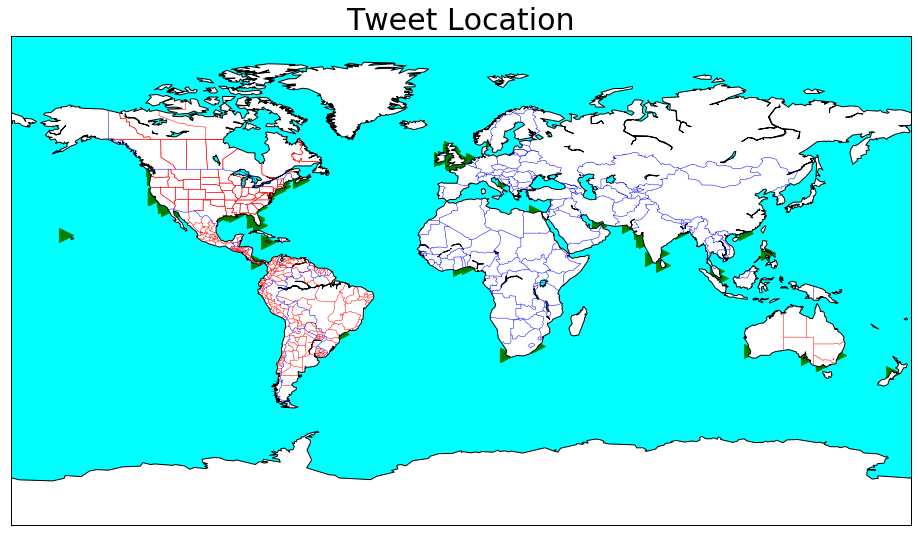

```python
from mpl_toolkits.basemap import Basemap
import matplotlib.pyplot as plt
fig = plt.figure(figsize=(20,9))
m = Basemap(projection='gall',
            resolution = 'c')
m.drawcoastlines()
m.drawcountries(color= 'blue')
m.drawstates(color= 'red')
m.drawmapboundary(fill_color='aqua')
m.fillcontinents(color='white',lake_color='aqua')
plt.title("Tweet Location",fontsize = 30)
Lat = list(ZLG["Latitude"])
Long = list(ZLG["Longitude"])
m.scatter(Long,Lat,latlon=True,color="green",marker = ">",s = 200)
plt.show()
```

# Discussions

Starting off with this project, we ran into quite a few roadblocks. We needed the amount of followers a user had for our tweet rating metric and the user location to test our second and third hypotheses. After spending almost the entire day on Thursday trying to find ways to pull user info from our tweets and joining it to our original DataFrame, we had to scratch the idea and move in a different direction. However, we were still very interested in our first hypothesis regarding the number of tweets and Trumps' approval rating - so we went ahead and worked on this part without followers or location. We made visualizations with two y-axes to compare the approval ratings by week (our third party data) and spent most of the day Friday creating new DataFrames that broke down specific keywords, polarity scores, or a combination of the two. We were then able to produce visualizations to test our remaining hypotheses - which will be discussed below.

Another issue we ran into had to do with the number of tweets we originally scraped - we scraped for 2000 instances of our keyword per week for 17 weeks with 9 keywords, which gave us about 300,000 tweets in our final DataFrame. Working with a DataFrame of this size in our virtual containers proved to be extremely inefective, so we figured the best course of action would be to eliminate some keywords and scrape less tweets per week to ensure we still got the same distribution of tweets per week.

# Conclusions

1) President Trump’s approval rating has increased with the number of “positive sentiment” tweets about the stimulus checks distributed by the US government. The more tweets involving stimulus checks that have highly rated words as determined by sentiment analysis, the higher we believe Trump’s approval rating will be. Then see how these results relate in our election simulation.

2) Sentiment ratings for the tweets will show an increase after the stimulus checks actually start to be distributed.

- We were able to explore this via sections 3.5.3, 3.5.4, and 3.5.5. We were not able to see a clear decrease in negative sentiment tweets after the stimulus checks were announced, or when they started to be distributed. We would have expected to see a sharp drop in our red line (number of negative tweets) after around week 12 or 13, but this did not occur on any of our plots.